# Lasy losowe

Łukasz Brzozowski

27.05.2019

#Prezentacja danych

```r
dat <- titanic
dat$age <- as.integer(dat$age)
dat$survived <- as.factor(dat$survived)
dat$class <- as.factor(dat$class)
summarizeColumns(dat)
```

| name | type | na | mean | disp | median | mad | min | max | nlevs |
| --- | --- | --- | --- | --- | --- | --- | --- | --- | --- |
| gender | factor | 0 | NA | 0.2215677 | NA | NA | 489 | 1718.0000 | 2 |
| age | integer | 2 | 30.4335601 | 12.1675298 | 29.0000 | 10.37820 | 0 | 74.0000 | 0 |
| class | factor | 0 | NA | 0.6787494 | NA | NA | 66 | 709.0000 | 7 |
| embarked | factor | 0 | NA | 0.2677843 | NA | NA | 123 | 1616.0000 | 4 |
| country | factor | 81 | NA | NA | NA | NA | 1 | 1125.0000 | 48 |
| fare | numeric | 26 | 19.7732901 | 43.4024538 | 7.1506 | 10.60148 | 0 | 512.0607 | 0 |
| sibsp | numeric | 10 | 0.2972235 | 0.8403836 | 0.0000 | 0.00000 | 0 | 8.0000 | 0 |
| parch | numeric | 10 | 0.2294037 | 0.6942322 | 0.0000 | 0.00000 | 0 | 9.0000 | 0 |
| survived | factor | 0 | NA | 0.3221568 | NA | NA | 711 | 1496.0000 | 2 |

```r
TestInx <- sample(nrow(dat), size = 0.3*nrow(dat))
datTrain <- dat[-TestInx,]
datTest <- dat[TestInx,]
datTrain <- na.omit(datTrain)
datTest <- na.omit(datTest)
dat <- na.omit(dat)
```

Przedstawione dane dotyczą przeżywalności osób obecnych na statku podczas katastrofy Tytanika. W ramce obecnych jest pięć zmiennych kategorycznych, w tym zmienna celu `survived` oraz cztery zmienne numeryczne. W niewielkim procencie w ramce występują braki danych, które można bezstratnie usunąć. Do klasyfikacji użyjemy modelu `rpart`.

# 1 Modele

## 1.1 Parametry z artykułu

Na początku zbudujemy model lasu losowego z hiperparametrami podanymi w artykule. Model oprzemy na implementacji `rpart`. Parametry to:

- `minsplit` = 24 - najmniejsza liczba obserwacji potrzebna do wykonania operacji `split`,
- `minbucket` = 12 - najmniejsza liczba obserwacji w każdym liściu drzewa,
- `cp` = 0 - współczynnik zaawansowania modelu,
- `maxdepth` = 21 - największa głębokość drzewa.

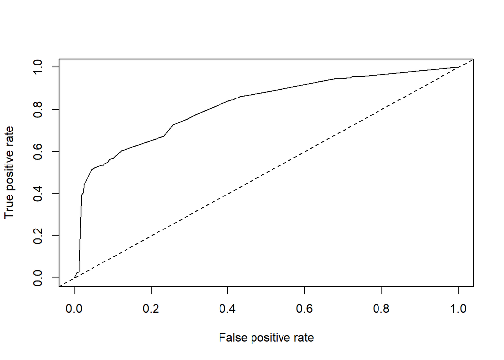

```r
set.seed(1)
pars <- rpart.control(minsplit = 24, minbucket = 12, cp = 0, maxdepth = 21)

model1 <- rpart(survived ~. , method = "class", data = datTrain, control = pars)

res1 <- predict(model1, newdata = datTest, type = "prob")
pred1 <- prediction( res1[, 2], datTest$survived)
perf1 <- performance(pred1, "tpr", "fpr")
perf1_1 <- performance(pred1, "auc")
plot(perf1)
abline(0, 1, lty = 2)
```

```r
slot(perf1_1, "y.values")
```

```
## [[1]]
## [1] 0.8182036
```

Jak widzimy, przy pomocy hiperparametrów z artykułu otrzymujemy AUC w wysokości prawie 82%.

## 1.2 Domyślne parametry

Zbudujemy teraz model z domyślnymi parametrami implementacji pakietu `rpart`.

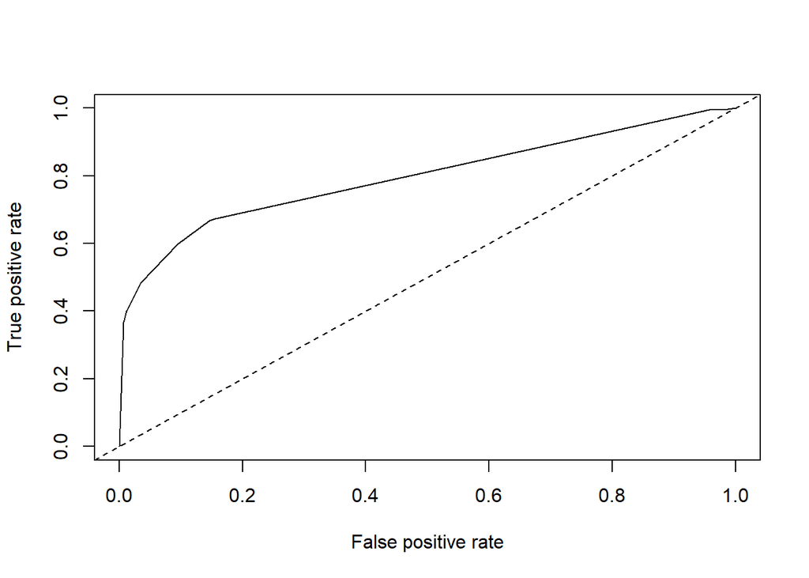

```r
set.seed(1)
model2 <- rpart(survived ~. , method = "class", data = datTrain)
res2 <- predict(model2, newdata = datTest, type = "prob")
pred2 <- prediction( res2[, 2], datTest$survived)
perf2 <- performance(pred2, "tpr", "fpr")
perf2_1 <- performance(pred2, "auc")
plot(perf2)
abline(0, 1, lty = 2)
```

```r
slot(perf2_1, "y.values")
```

```
## [[1]]
## [1] 0.7959147
```

Otrzymany model ma bardzo podobne wyniki do uzyskanego z parametrami z artykułu, jednak skuteczność jest o ponad jeden punkt procentowy gorsza.

## 1.3 Random search

Ostatecznie przygotujemy model przy pomocy przeszukiwania losowego przestrzeni hiperparametrów. Będziemy przeszukiwać parametry podane w artykule, ponieważ to umożliwi nam łatwe porównanie wyników.

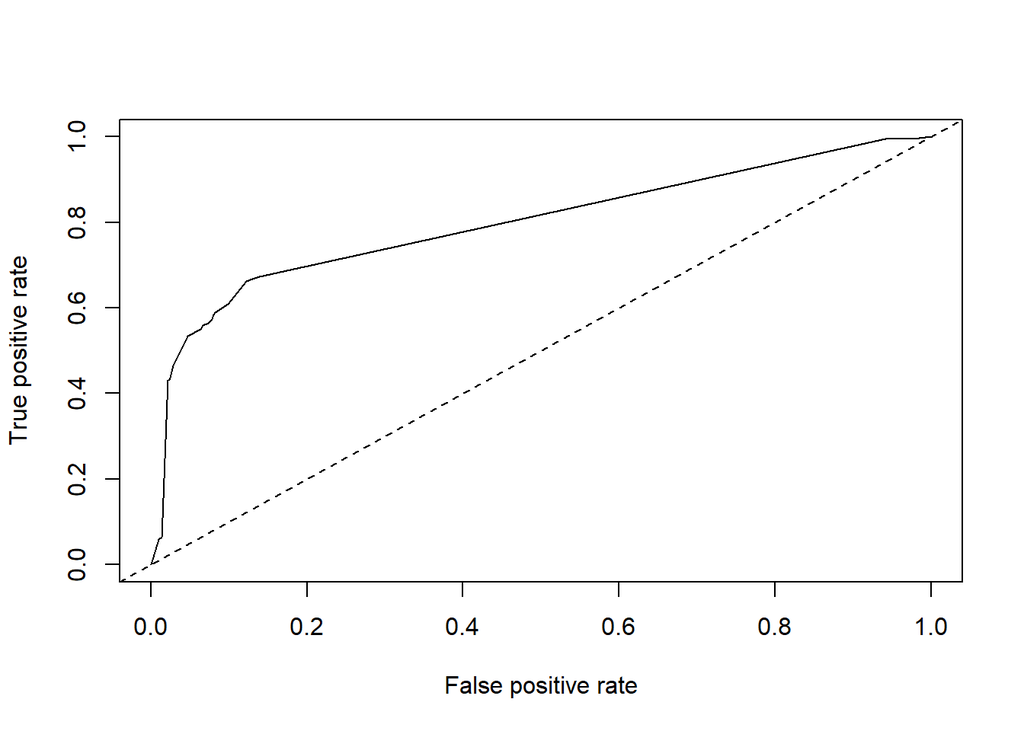

```r
set.seed(1)
classifTask3 <- makeClassifTask(id = "rpart1", data = datTrain, target = "survived")
classifLrn3 <- makeLearner("classif.rpart", predict.type = "prob")

cv <- makeResampleDesc("CV", iters = 5L)
ctrlRandom <- makeTuneControlRandom(maxit = 1000L)

rfPms <- makeParamSet(
  makeNumericParam("cp", lower = 0, upper = 0.2),
  makeIntegerParam("maxdepth", lower = 2, upper = 50),
  makeIntegerParam("minbucket", lower = 2, upper = 50),
  makeIntegerParam("minsplit", lower = 2, upper = 50)
  )

rpartRes <- tuneParams(classifLrn3, task = classifTask3, measures = list(acc, auc), resampling = cv, par.set = rfPms, control = ctrlRandom)

model3 <-  rpart(survived ~. , method = "class", data = datTrain, control = rpartRes$x)

res3 <- predict(model3, newdata = datTest, type = "prob")
pred3 <- prediction( res3[, 2], datTest$survived)
perf3 <- performance(pred3, "tpr", "fpr")
perf3_1 <- performance(pred3, "auc")
plot(perf3)
abline(0, 1, lty = 2)
```

```r
slot(perf3_1, "y.values")
```

```
## [[1]]
## [1] 0.7981155
```

## 1.4 Najlepsze drzewo

Możemy sprawdzić, jak wygląda najlepsze drzewo

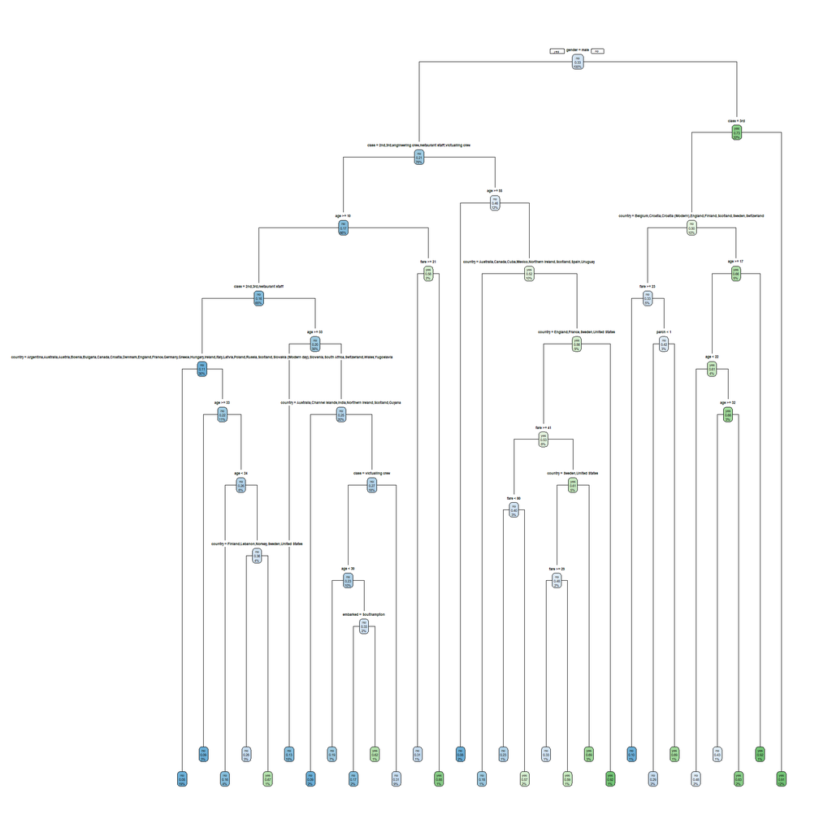

```r
rpart.plot(model1, type = 1)
```

## 1.5 Porównanie kryteriów podziału

Teraz porównajmy wyniki drzew dzielących etykiety według różnych kryteriów podziału. Implementacja `classif.rpart` udostępnia dwie możliwe zasady dzielenia - `gini` oraz `information`.

### 1.5.1 `information`

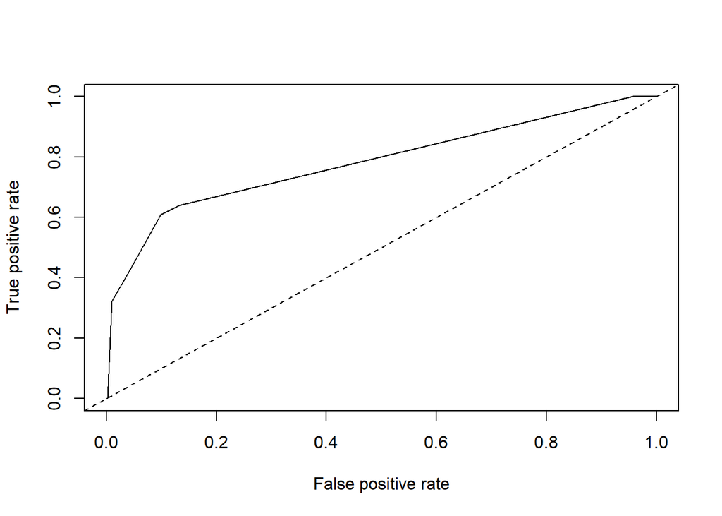

```r
model4 <- rpart(survived ~. , method = "class", data = datTrain, parms = list(split = "information"))
res4 <- predict(model4, newdata = datTest, type = "prob")
pred4 <- prediction( res4[, 2], datTest$survived)
perf4 <- performance(pred4, "tpr", "fpr")
perf4_1 <- performance(pred4, "auc")
plot(perf4)
abline(0, 1, lty = 2)
```

```r
slot(perf4_1, "y.values")
```

```
## [[1]]
## [1] 0.7821374
```

### 1.5.2 `gini`

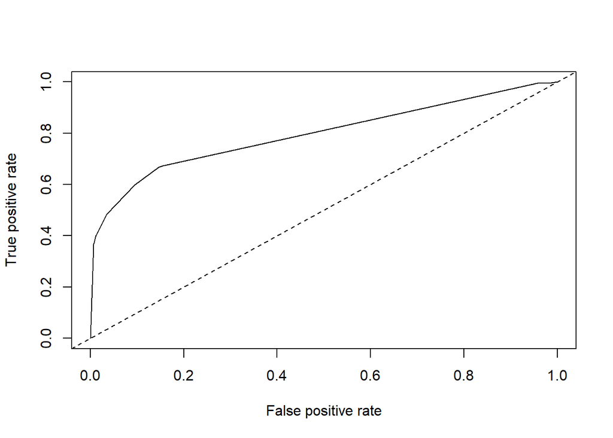

```r
model5 <- rpart(survived ~. , method = "class", data = datTrain, parms = list(split = "gini"))
res5 <- predict(model5, newdata = datTest, type = "prob")
pred5 <- prediction( res5[, 2], datTest$survived)
perf5 <- performance(pred5, "tpr", "fpr")
perf5_1 <- performance(pred5, "auc")
plot(perf5)
abline(0, 1, lty = 2)
```

```r
slot(perf5_1, "y.values")
```

```
## [[1]]
## [1] 0.7959147
```

Jak widzimy, wyniki osiągnięte przy pomocy metody dzielącej `gini` są nieznacznie lepsze od metody `information gain`, osiągając ponad 79% AUC.

# 2 Porównanie z `ctree`

Na koniec porównajmy osiągnięty model z modelem `ctree` na domyślnych parametrach.

```r
classifTask7 <- makeClassifTask(id = "rf2", data = datTrain, target = "survived")
classifLrn7 <- makeLearner("classif.ctree", predict.type = "prob")
r <- resample(classifLrn7, classifTask7, cv5, measures = list(acc, auc))
r$aggr
```

```
## acc.test.mean auc.test.mean
##     0.7786487     0.7824124
```